# Cycle-walk convergence bisection study

- Show All Code
- Hide All Code
- View Source

Do independent standard cycle walks agree along the (γ, iso) line?

Author

Jonathan Mattingly

Published

July 12, 2026

```
  Activating project at `~/Git/MergeAnneledTemp/CycleWalk.jl/examples/validation/report`
```

## Question

For the **standard cycle walk** (Metropolis–Hastings on the fixed target, *not* AIS), how sharp can the target measure get before independent chains stop agreeing? We probe along the line **γ = t, iso = 0.3·t**, $t \in [0,1]$, from a flat base ($t=0$) to a sharp target ($t=1$).

At each point we run **8 independent copies** (distinct seeds), **20,000 samples** each, spacing 1000 MH steps, and compare the **rank-ordered marginals of the per-district log spanning-tree count** (`get_log_spanning_trees`, sorted ascending per plan).

**Verdict rule.** CONVERGED iff, for *every* district rank, the max pairwise total-variation distance between the 8 copies’ binned marginals stays within the split-half noise floor, $\text{maxTV} \le 2\,\text{noise} + 0.02$. Bisection tests the endpoints first (expecting $t=0$ CONVERGED, $t=1$ NOT), then bisects to bracket the break.

## Headline result

**The bisection never triggered — the cycle walk converges across the entire line on both graphs.** Both endpoints came back CONVERGED, so there is no critical $t^\*$ to bracket in $[0,1]$; the driver’s STRICT guard stopped before bisecting.

| Case | $t=0$ | $t=1$ | transition |
| --- | --- | --- | --- |
| Grid (10×10, 3 dist) | CONVERGED | CONVERGED | none |
| CT (5 dist) | CONVERGED | CONVERGED | none |

## Grid (10×10, 3 districts)

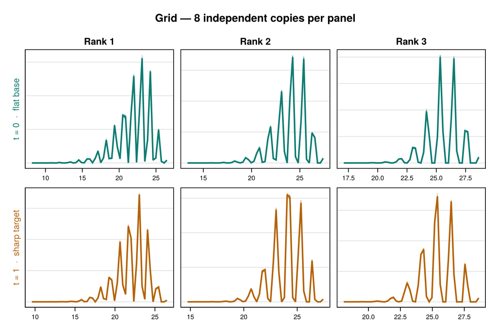

Figure 1: Grid: rank-ordered log-spanning-tree marginals, 8 copies overlaid (translucent) with the pointwise mean (solid). Top row t=0, bottom row t=1. A single tight band = the chains agree.

```julia
overlay(grid, [1, 2, 3]; title = "Grid — 8 independent copies per panel")
```

The grid is essentially flat from base to sharp target — the copy-mean spread is ≈ 0.03–0.05 nats at both ends. The 3-district / 100-node graph is too small to strain the sampler anywhere.

Verdict stats (`maxTV` = between-copy TV; `2·noise` = pass threshold; `meanΔ` = copy-mean spread, nats):

| point | rank | maxTV | 2·noise | maxKS | meanΔ |
| --- | --- | --- | --- | --- | --- |
| t=0 | 1 | 0.0207 | 0.0549 | 0.0166 | 0.054 |
| t=0 | 2 | 0.0184 | 0.0545 | 0.0144 | 0.047 |
| t=0 | 3 | 0.0234 | 0.0533 | 0.0160 | 0.028 |
| t=1 | 1 | 0.0191 | 0.0667 | 0.0114 | 0.035 |
| t=1 | 2 | 0.0165 | 0.0503 | 0.0141 | 0.028 |
| t=1 | 3 | 0.0202 | 0.0601 | 0.0141 | 0.023 |

## CT (5 districts)

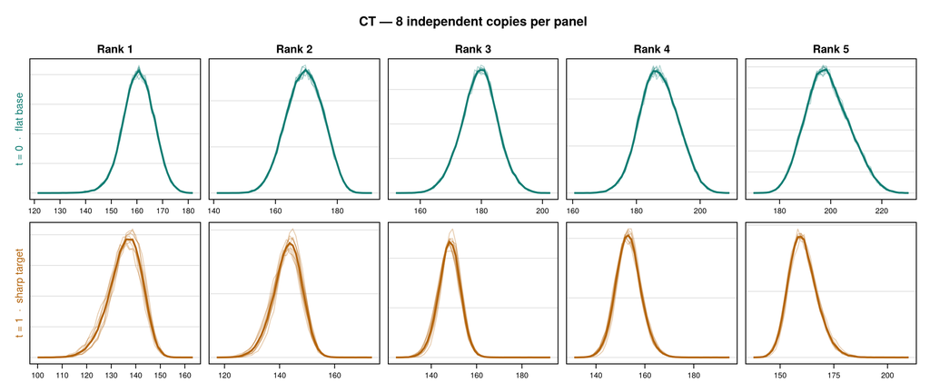

Figure 2: Connecticut: same overlay, 5 district ranks. The t=0 row is a single tight band; in the t=1 row the bands widen and the copies begin to pull apart — the sampler is straining at the sharp target, though still within its own noise floor.

```julia
overlay(ct, [1, 2, 3, 4, 5]; title = "CT — 8 independent copies per panel")
```

CT passes the verdict at both ends, but the mixing clearly gets harder as $t \to 1$:

| point | rank | maxTV | 2·noise | maxKS | meanΔ |
| --- | --- | --- | --- | --- | --- |
| t=0 | 1 | 0.0219 | 0.0557 | 0.0151 | 0.174 |
| t=0 | 3 | 0.0243 | 0.0657 | 0.0133 | 0.131 |
| t=0 | 5 | 0.0235 | 0.0703 | 0.0197 | 0.333 |
| t=1 | 1 | 0.1602 | 0.5367 | 0.1615 | **2.66** |
| t=1 | 2 | 0.1713 | 0.4619 | 0.1726 | **2.19** |
| t=1 | 3 | 0.1512 | 0.3722 | 0.1534 | **1.78** |
| t=1 | 4 | 0.1090 | 0.2246 | 0.1094 | **1.37** |
| t=1 | 5 | 0.0726 | 0.1619 | 0.0739 | **1.26** |

| CT metric (max over ranks) | $t=0$ | $t=1$ | change |
| --- | --- | --- | --- |
| between-copy meanΔ (nats) | ~0.1–0.3 | 1.3–2.7 | **~10–20×** |
| within-chain floor 2·noise | ~0.06 | 0.16–0.54 | **~10×** |
| between-copy maxTV | ~0.02 | 0.07–0.17 | ~7× |

Because the verdict is **relative** (between-copy TV vs the chain’s own split-half noise), the gate gets *easier to pass* exactly as mixing worsens — which is why CT $t=1$ reads CONVERGED despite a 2.7-nat mean spread.

## Interpretation

The **AIS weight collapse observed earlier was an importance-weighting / annealing-schedule problem, not a failure of the underlying cycle walk to mix.** As a direct sampler at the fixed target, the walk stays self-consistent across independent runs over the whole (γ, iso) line, on both graphs. The graceful CT slow-down marks where a harder case (NC, 14 districts) or a longer run would push it past breaking.

## Next steps

1. **Define the break we want.** The current gate is relative. If the interest is *mixing rate*, switch to an **absolute** criterion (fixed ESS or fixed TV tolerance) — that would flip CT $t=1$ to a fail and give the bisection an actual $t^\*$ to bracket.
2. **Run NC (14 districts).** The true stress case, where AIS collapsed hardest. The rig is ready: `CASE=nc bash validation/hpc/run_bisection_study.sh`.
3. **Sample budget.** The CT $t=1$ slow-down is visible but sub-floor at 20k; a longer run would resolve whether the copies genuinely agree or eventually separate.